# iris

## About the Data

##### The dataset contains information about three species of irises: Iris setosa, Iris versicolor, and Iris virginica.

##### The data includes measurements of four features: sepal length, sepal width, petal length, and petal width.

##### Each row in the dataset represents a single flower, with measurement values given in centimeters.

##### The dataset consists of 150 samples, with 50 samples for each species, and is widely used as a basic dataset for testing classification

##### algorithms and in data science and machine learning.

##### Columns:

- **sepal length** - Sepal length in cm
- **sepal width** - Sepal width in cm
- **petal length** - Petal length in cm
- **petal width** - Petal width in cm
- **class** - Iris species (setosa, versicolor, virginica)

```python
import pandas as pd
import seaborn as sns
import matplotlib.pyplot as plt
```

```python
df = pd.read_csv('25__iris.csv', sep=",")
df
```

|  | długość kielicha (sepal length) | szerokość kielicha (sepal width) | długość płatka (petal length) | szerokość płatka (petal width) | klasa (class) |
| --- | --- | --- | --- | --- | --- |
| 0 | 5.1 | 3.5 | 1.4 | 0.2 | Iris-setosa |
| 1 | 4.9 | 3.0 | 1.4 | 0.2 | Iris-setosa |
| 2 | 4.7 | 3.2 | 1.3 | 0.2 | Iris-setosa |
| 3 | 4.6 | 3.1 | 1.5 | 0.2 | Iris-setosa |
| 4 | 5.0 | 3.6 | 1.4 | 0.2 | Iris-setosa |
| ... | ... | ... | ... | ... | ... |
| 145 | 6.7 | 3.0 | 5.2 | 2.3 | Iris-virginica |
| 146 | 6.3 | 2.5 | 5.0 | 1.9 | Iris-virginica |
| 147 | 6.5 | 3.0 | 5.2 | 2.0 | Iris-virginica |
| 148 | 6.2 | 3.4 | 5.4 | 2.3 | Iris-virginica |
| 149 | 5.9 | 3.0 | 5.1 | 1.8 | Iris-virginica |

150 rows × 5 columns

# 1. General Data Overview.

```python
# Insight into the first 15 rows
df.head(15)
```

|  | długość kielicha (sepal length) | szerokość kielicha (sepal width) | długość płatka (petal length) | szerokość płatka (petal width) | klasa (class) |
| --- | --- | --- | --- | --- | --- |
| 0 | 5.1 | 3.5 | 1.4 | 0.2 | Iris-setosa |
| 1 | 4.9 | 3.0 | 1.4 | 0.2 | Iris-setosa |
| 2 | 4.7 | 3.2 | 1.3 | 0.2 | Iris-setosa |
| 3 | 4.6 | 3.1 | 1.5 | 0.2 | Iris-setosa |
| 4 | 5.0 | 3.6 | 1.4 | 0.2 | Iris-setosa |
| 5 | 5.4 | 3.9 | 1.7 | 0.4 | Iris-setosa |
| 6 | 4.6 | 3.4 | 1.4 | 0.3 | Iris-setosa |
| 7 | 5.0 | 3.4 | 1.5 | 0.2 | Iris-setosa |
| 8 | 4.4 | 2.9 | 1.4 | 0.2 | Iris-setosa |
| 9 | 4.9 | 3.1 | 1.5 | 0.1 | Iris-setosa |
| 10 | 5.4 | 3.7 | 1.5 | 0.2 | Iris-setosa |
| 11 | 4.8 | 3.4 | 1.6 | 0.2 | Iris-setosa |
| 12 | 4.8 | 3.0 | 1.4 | 0.1 | Iris-setosa |
| 13 | 4.3 | 3.0 | 1.1 | 0.1 | Iris-setosa |
| 14 | 5.8 | 4.0 | 1.2 | 0.2 | Iris-setosa |

```python
# Insight into the last 15 rows
df.tail(15)
```

|  | długość kielicha (sepal length) | szerokość kielicha (sepal width) | długość płatka (petal length) | szerokość płatka (petal width) | klasa (class) |
| --- | --- | --- | --- | --- | --- |
| 135 | 7.7 | 3.0 | 6.1 | 2.3 | Iris-virginica |
| 136 | 6.3 | 3.4 | 5.6 | 2.4 | Iris-virginica |
| 137 | 6.4 | 3.1 | 5.5 | 1.8 | Iris-virginica |
| 138 | 6.0 | 3.0 | 4.8 | 1.8 | Iris-virginica |
| 139 | 6.9 | 3.1 | 5.4 | 2.1 | Iris-virginica |
| 140 | 6.7 | 3.1 | 5.6 | 2.4 | Iris-virginica |
| 141 | 6.9 | 3.1 | 5.1 | 2.3 | Iris-virginica |
| 142 | 5.8 | 2.7 | 5.1 | 1.9 | Iris-virginica |
| 143 | 6.8 | 3.2 | 5.9 | 2.3 | Iris-virginica |
| 144 | 6.7 | 3.3 | 5.7 | 2.5 | Iris-virginica |
| 145 | 6.7 | 3.0 | 5.2 | 2.3 | Iris-virginica |
| 146 | 6.3 | 2.5 | 5.0 | 1.9 | Iris-virginica |
| 147 | 6.5 | 3.0 | 5.2 | 2.0 | Iris-virginica |
| 148 | 6.2 | 3.4 | 5.4 | 2.3 | Iris-virginica |
| 149 | 5.9 | 3.0 | 5.1 | 1.8 | Iris-virginica |

```python
# Insight from row 49 to 64
df.iloc[49:64]
```

|  | długość kielicha (sepal length) | szerokość kielicha (sepal width) | długość płatka (petal length) | szerokość płatka (petal width) | klasa (class) |
| --- | --- | --- | --- | --- | --- |
| 49 | 5.0 | 3.3 | 1.4 | 0.2 | Iris-setosa |
| 50 | 7.0 | 3.2 | 4.7 | 1.4 | Iris-versicolor |
| 51 | 6.4 | 3.2 | 4.5 | 1.5 | Iris-versicolor |
| 52 | 6.9 | 3.1 | 4.9 | 1.5 | Iris-versicolor |
| 53 | 5.5 | 2.3 | 4.0 | 1.3 | Iris-versicolor |
| 54 | 6.5 | 2.8 | 4.6 | 1.5 | Iris-versicolor |
| 55 | 5.7 | 2.8 | 4.5 | 1.3 | Iris-versicolor |
| 56 | 6.3 | 3.3 | 4.7 | 1.6 | Iris-versicolor |
| 57 | 4.9 | 2.4 | 3.3 | 1.0 | Iris-versicolor |
| 58 | 6.6 | 2.9 | 4.6 | 1.3 | Iris-versicolor |
| 59 | 5.2 | 2.7 | 3.9 | 1.4 | Iris-versicolor |
| 60 | 5.0 | 2.0 | 3.5 | 1.0 | Iris-versicolor |
| 61 | 5.9 | 3.0 | 4.2 | 1.5 | Iris-versicolor |
| 62 | 6.0 | 2.2 | 4.0 | 1.0 | Iris-versicolor |
| 63 | 6.1 | 2.9 | 4.7 | 1.4 | Iris-versicolor |

##### It looks like every 50 consecutive columns are dedicated to one species.

```python
df.info()
```

```
<class 'pandas.core.frame.DataFrame'>
RangeIndex: 150 entries, 0 to 149
Data columns (total 5 columns):
 #   Column                            Non-Null Count  Dtype
---  ------                            --------------  -----
 0   długość kielicha (sepal length)   150 non-null    float64
 1   szerokość kielicha (sepal width)  150 non-null    float64
 2   długość płatka (petal length)     150 non-null    float64
 3   szerokość płatka (petal width)    150 non-null    float64
 4   klasa (class)                     150 non-null    object
dtypes: float64(4), object(1)
memory usage: 6.0+ KB
```

##### The DataFrame has 150 rows, indexed from 0 to 149.

##### There are 5 columns in total: 4 columns (float) and 1 column (string).

##### There are no missing values (no data gaps / NaN) in any column.

```python
# Checking the number of unique values
df.nunique()
```

```
długość kielicha (sepal length)     35
szerokość kielicha (sepal width)    23
długość płatka (petal length)       43
szerokość płatka (petal width)      22
klasa (class)                        3
dtype: int64
```

##### Seeing the number of unique values, it’s clear that the length of petals and sepals is much more varied than their width.

```python
# Checking the number of records for each class
df.groupby('klasa (class)').count()
```

| klasa (class) | długość kielicha (sepal length) | szerokość kielicha (sepal width) | długość płatka (petal length) | szerokość płatka (petal width) |
| --- | --- | --- | --- | --- |
| Iris-setosa | 50 | 50 | 50 | 50 |
| Iris-versicolor | 50 | 50 | 50 | 50 |
| Iris-virginica | 50 | 50 | 50 | 50 |

##### Each class of flowers has the same number of samples. We have 50 measurements for each species.

```python
# Displaying descriptive statistics for numerical columns in the DataFrame such as:
# count, mean, standard deviation, minimum value, 25th percentile, median, 75th percentile, maximum value
```

```python
df.describe()
```

|  | długość kielicha (sepal length) | szerokość kielicha (sepal width) | długość płatka (petal length) | szerokość płatka (petal width) |
| --- | --- | --- | --- | --- |
| count | 150.000000 | 150.000000 | 150.000000 | 150.000000 |
| mean | 5.843333 | 3.054000 | 3.758667 | 1.198667 |
| std | 0.828066 | 0.433594 | 1.764420 | 0.763161 |
| min | 4.300000 | 2.000000 | 1.000000 | 0.100000 |
| 25% | 5.100000 | 2.800000 | 1.600000 | 0.300000 |
| 50% | 5.800000 | 3.000000 | 4.350000 | 1.300000 |
| 75% | 6.400000 | 3.300000 | 5.100000 | 1.800000 |
| max | 7.900000 | 4.400000 | 6.900000 | 2.500000 |

```python
# Changing the table format to make it more readable
cm= sns.light_palette("green", as_cmap= True)
df.describe().T.style.background_gradient(cmap=cm, axis=1, subset=["mean", "std", "min", "50%", "75%", "max"])
```

|  | count | mean | std | min | 25% | 50% | 75% | max |
| --- | --- | --- | --- | --- | --- | --- | --- | --- |
| długość kielicha (sepal length) | 150.000000 | 5.843333 | 0.828066 | 4.300000 | 5.100000 | 5.800000 | 6.400000 | 7.900000 |
| szerokość kielicha (sepal width) | 150.000000 | 3.054000 | 0.433594 | 2.000000 | 2.800000 | 3.000000 | 3.300000 | 4.400000 |
| długość płatka (petal length) | 150.000000 | 3.758667 | 1.764420 | 1.000000 | 1.600000 | 4.350000 | 5.100000 | 6.900000 |
| szerokość płatka (petal width) | 150.000000 | 1.198667 | 0.763161 | 0.100000 | 0.300000 | 1.300000 | 1.800000 | 2.500000 |

# 2. Data Cleaning

```python
# Checking for missing values
```

```python
df.isnull().sum()
```

```
długość kielicha (sepal length)     0
szerokość kielicha (sepal width)    0
długość płatka (petal length)       0
szerokość płatka (petal width)      0
klasa (class)                       0
dtype: int64
```

```python
# According to the preliminary analysis, all cells are filled with data.
# Now let's check for duplicates.
```

```python
df[df.duplicated()]
```

|  | długość kielicha (sepal length) | szerokość kielicha (sepal width) | długość płatka (petal length) | szerokość płatka (petal width) | klasa (class) |
| --- | --- | --- | --- | --- | --- |
| 34 | 4.9 | 3.1 | 1.5 | 0.1 | Iris-setosa |
| 37 | 4.9 | 3.1 | 1.5 | 0.1 | Iris-setosa |
| 142 | 5.8 | 2.7 | 5.1 | 1.9 | Iris-virginica |

```python
# We have three duplicates, but we don’t know if this is accidental or true duplicates.
# Since these records constitute only 2%, we will keep them in the DataFrame.
```

```python
# Changing column names to shorter ones
```

```python
df.rename(columns={"długość kielicha (sepal length)": "sepal length",
                   "szerokość kielicha (sepal width)": "sepal width",
                   "długość płatka (petal length)":"petal length",
                   "szerokość płatka (petal width)":"petal width",
                   "klasa (class)": "class"}, inplace=True)
df
```

|  | sepal length | sepal width | petal length | petal width | class |
| --- | --- | --- | --- | --- | --- |
| 0 | 5.1 | 3.5 | 1.4 | 0.2 | Iris-setosa |
| 1 | 4.9 | 3.0 | 1.4 | 0.2 | Iris-setosa |
| 2 | 4.7 | 3.2 | 1.3 | 0.2 | Iris-setosa |
| 3 | 4.6 | 3.1 | 1.5 | 0.2 | Iris-setosa |
| 4 | 5.0 | 3.6 | 1.4 | 0.2 | Iris-setosa |
| ... | ... | ... | ... | ... | ... |
| 145 | 6.7 | 3.0 | 5.2 | 2.3 | Iris-virginica |
| 146 | 6.3 | 2.5 | 5.0 | 1.9 | Iris-virginica |
| 147 | 6.5 | 3.0 | 5.2 | 2.0 | Iris-virginica |
| 148 | 6.2 | 3.4 | 5.4 | 2.3 | Iris-virginica |
| 149 | 5.9 | 3.0 | 5.1 | 1.8 | Iris-virginica |

150 rows × 5 columns

```python
# 3. Data Analysis
```

```python
# To take a closer look at the data, I display descriptive statistics separately for each variety
# For the Iris-setosa class
cm= sns.light_palette("green", as_cmap= True)
df[df["class"] == "Iris-setosa"].describe().style.set_caption("Iris-setosa").background_gradient(cmap=cm, axis=1)
```

Iris-setosa

|  | sepal length | sepal width | petal length | petal width |
| --- | --- | --- | --- | --- |
| count | 50.000000 | 50.000000 | 50.000000 | 50.000000 |
| mean | 5.006000 | 3.418000 | 1.464000 | 0.244000 |
| std | 0.352490 | 0.381024 | 0.173511 | 0.107210 |
| min | 4.300000 | 2.300000 | 1.000000 | 0.100000 |
| 25% | 4.800000 | 3.125000 | 1.400000 | 0.200000 |
| 50% | 5.000000 | 3.400000 | 1.500000 | 0.200000 |
| 75% | 5.200000 | 3.675000 | 1.575000 | 0.300000 |
| max | 5.800000 | 4.400000 | 1.900000 | 0.600000 |

```python
# For the Iris-versicolor class
cm=sns.light_palette("green", as_cmap=True)
df[df["class"] == "Iris-versicolor"].describe().style.set_caption("Iris-versicolor").background_gradient(cmap=cm, axis=1)
```

Iris-versicolor

|  | sepal length | sepal width | petal length | petal width |
| --- | --- | --- | --- | --- |
| count | 50.000000 | 50.000000 | 50.000000 | 50.000000 |
| mean | 5.936000 | 2.770000 | 4.260000 | 1.326000 |
| std | 0.516171 | 0.313798 | 0.469911 | 0.197753 |
| min | 4.900000 | 2.000000 | 3.000000 | 1.000000 |
| 25% | 5.600000 | 2.525000 | 4.000000 | 1.200000 |
| 50% | 5.900000 | 2.800000 | 4.350000 | 1.300000 |
| 75% | 6.300000 | 3.000000 | 4.600000 | 1.500000 |
| max | 7.000000 | 3.400000 | 5.100000 | 1.800000 |

```python
# For the Iris-virginica class
# dla klasy Iris-virginica
df[df["class"] == "Iris-virginica"].describe().style.set_caption("Iris-virginica").background_gradient(cmap=cm, axis=1)
```

Iris-virginica

|  | sepal length | sepal width | petal length | petal width |
| --- | --- | --- | --- | --- |
| count | 50.000000 | 50.000000 | 50.000000 | 50.000000 |
| mean | 6.588000 | 2.974000 | 5.552000 | 2.026000 |
| std | 0.635880 | 0.322497 | 0.551895 | 0.274650 |
| min | 4.900000 | 2.200000 | 4.500000 | 1.400000 |
| 25% | 6.225000 | 2.800000 | 5.100000 | 1.800000 |
| 50% | 6.500000 | 3.000000 | 5.550000 | 2.000000 |
| 75% | 6.900000 | 3.175000 | 5.875000 | 2.300000 |
| max | 7.900000 | 3.800000 | 6.900000 | 2.500000 |

```python
# Now I will compare length and width together for the 3 classes
# sepal length
cm=sns.light_palette("green", as_cmap= True)
(
df.groupby("class")["sepal length"]
.describe()
.style
.set_caption("Sepal Length")
.background_gradient(
    cmap=cm, axis=1,
    subset=["mean", "std", "min", "50%", "75%", "max"]
    )
)
```

Sepal Length

| class | count | mean | std | min | 25% | 50% | 75% | max |
| --- | --- | --- | --- | --- | --- | --- | --- | --- |
| Iris-setosa | 50.000000 | 5.006000 | 0.352490 | 4.300000 | 4.800000 | 5.000000 | 5.200000 | 5.800000 |
| Iris-versicolor | 50.000000 | 5.936000 | 0.516171 | 4.900000 | 5.600000 | 5.900000 | 6.300000 | 7.000000 |
| Iris-virginica | 50.000000 | 6.588000 | 0.635880 | 4.900000 | 6.225000 | 6.500000 | 6.900000 | 7.900000 |

##### Ranges (min – max)

- Setosa: 4.3 – 5.8
- Versicolor: 4.9 – 7.0
- Virginica: 4.9 – 7.9

The ranges overlap. For example, a value of 5.0 can occur in both Setosa and Versicolor.

##### Final conclusions:

- Sepal length increases on average from Setosa through Versicolor to Virginica.
- However, these features have overlapping ranges, so classes cannot be distinguished based solely on this one feature.
- Setosa is the most uniform, while Virginica is the most diverse.

```python
# sepal with
(
df.groupby('class')['sepal width']
.describe()
.style
.set_caption("Sepal Width")
.background_gradient(
    cmap=cm, axis=1,
    subset=["mean", "std", "min", "50%", "75%", "max"]
    )
)
```

Sepal Width

| class | count | mean | std | min | 25% | 50% | 75% | max |
| --- | --- | --- | --- | --- | --- | --- | --- | --- |
| Iris-setosa | 50.000000 | 3.418000 | 0.381024 | 2.300000 | 3.125000 | 3.400000 | 3.675000 | 4.400000 |
| Iris-versicolor | 50.000000 | 2.770000 | 0.313798 | 2.000000 | 2.525000 | 2.800000 | 3.000000 | 3.400000 |
| Iris-virginica | 50.000000 | 2.974000 | 0.322497 | 2.200000 | 2.800000 | 3.000000 | 3.175000 | 3.800000 |

##### 1. Mean

- Setosa: 3.42 → highest
- Virginica: 2.97 → intermediate
- Versicolor: 2.77 → lowest

##### Setosa clearly has wider sepals than the other classes.

##### The ranges of max and min values overlap significantly – e.g., values in the range 2.8–3.4 occur in all three classes.

##### This means that sepal width alone is not sufficient to reliably distinguish the classes.

##### Final conclusions:

- Setosa has noticeably wider sepals than the other species, which can be a useful feature for distinguishing it.
- Versicolor and Virginica have very similar distributions → making it harder to tell them apart based only on sepal width.
- This feature alone is not enough, but combined with others (e.g., petal length), it may help in classification.

```python
# petal length
(
df.groupby("class")["petal length"]
.describe()
.style
.set_caption("Petal Length")
.background_gradient(
    cmap=cm, axis=1,
    subset=["mean", "std", "min", "50%", "75%", "max"]
    )
)
```

Petal Length

| class | count | mean | std | min | 25% | 50% | 75% | max |
| --- | --- | --- | --- | --- | --- | --- | --- | --- |
| Iris-setosa | 50.000000 | 1.464000 | 0.173511 | 1.000000 | 1.400000 | 1.500000 | 1.575000 | 1.900000 |
| Iris-versicolor | 50.000000 | 4.260000 | 0.469911 | 3.000000 | 4.000000 | 4.350000 | 4.600000 | 5.100000 |
| Iris-virginica | 50.000000 | 5.552000 | 0.551895 | 4.500000 | 5.100000 | 5.550000 | 5.875000 | 6.900000 |

##### 1. Mean

- Setosa: 1.46 → very short petals.
- Versicolor: 4.26 → significantly longer.
- Virginica: 5.55 → longest.

##### The differences are very clear – petal length is excellent for distinguishing between classes.

2. Value range (min–max)
- Setosa: 1.0 – 1.9
- Versicolor: 3.0 – 5.1
- Virginica: 4.5 – 6.9

##### The ranges barely overlap:

##### Setosa is completely separated.

##### Versicolor and Virginica slightly touch (4.5–5.1), but are mostly distinct.

##### Final conclusions:

- Petal length is a very good feature for distinguishing Iris classes.
- Setosa is completely separated from the other two classes.
- Versicolor and Virginica have a small overlapping zone (4.5–5.1), but overall they are also well separated.
- This feature may be crucial for iris species classification.

```python
# petal width
(
df.groupby('class')['petal width']
.describe()
.style
.set_caption("Petal Width")
.background_gradient(
    cmap=cm, axis=1,
    subset=["mean", "std", "min", "50%", "75%", "max"]
    )
)
```

Petal Width

| class | count | mean | std | min | 25% | 50% | 75% | max |
| --- | --- | --- | --- | --- | --- | --- | --- | --- |
| Iris-setosa | 50.000000 | 0.244000 | 0.107210 | 0.100000 | 0.200000 | 0.200000 | 0.300000 | 0.600000 |
| Iris-versicolor | 50.000000 | 1.326000 | 0.197753 | 1.000000 | 1.200000 | 1.300000 | 1.500000 | 1.800000 |
| Iris-virginica | 50.000000 | 2.026000 | 0.274650 | 1.400000 | 1.800000 | 2.000000 | 2.300000 | 2.500000 |

##### 1. Mean

- Setosa: 0.24 → very narrow petals.
- Versicolor: 1.33 → more than 5 times wider than Setosa.
- Virginica: 2.03 → the widest of all.

##### The differences are huge and very clear.

##### 2. Value range (min–max)

- Setosa: 0.1 – 0.6
- Versicolor: 1.0 – 1.8
- Virginica: 1.4 – 2.5

##### Each class has its own “characteristic range.”

##### 4. Final conclusions

- Petal width is one of the best features for distinguishing iris species.
- Setosa is completely separated from the other classes.
- Versicolor and Virginica have a small overlap zone, but the differences in means and quartiles are large, so they are still easy to distinguish.

```
array([[<Axes: title={'center': 'petal length'}, xlabel='[class]'>,
        <Axes: title={'center': 'petal width'}, xlabel='[class]'>],
       [<Axes: title={'center': 'sepal length'}, xlabel='[class]'>,
        <Axes: title={'center': 'sepal width'}, xlabel='[class]'>]],
      dtype=object)
```

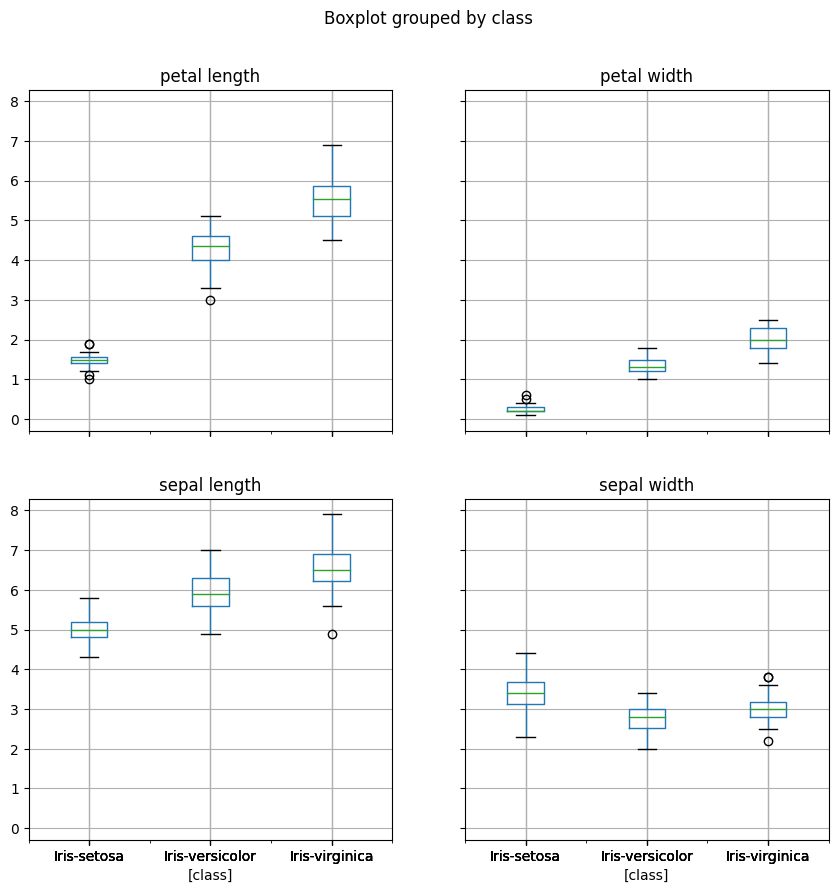

```python
df.boxplot(by="class", figsize=(10,10))
```

##### Petal width

- Setosa has very narrow petals.
- Versicolor and Virginica have noticeably wider petals, but slightly overlap in the range of 1.4–1.8 cm.
- Also a very good feature for distinguishing species.

##### Sepal length

- The mean gradually increases from Setosa → Versicolor → Virginica.
- Value ranges partially overlap, especially between Versicolor and Virginica.
- A moderately useful feature for classification.

##### Sepal width

- Setosa has slightly wider sepals, but there is high variability and overlap with other classes.
- The least distinctive feature — not well suited for classification.

##### The strongest differences between iris species concern the petals — both their length and width.

##### Sepal features are less significant and not sufficient on their own for clear classification.

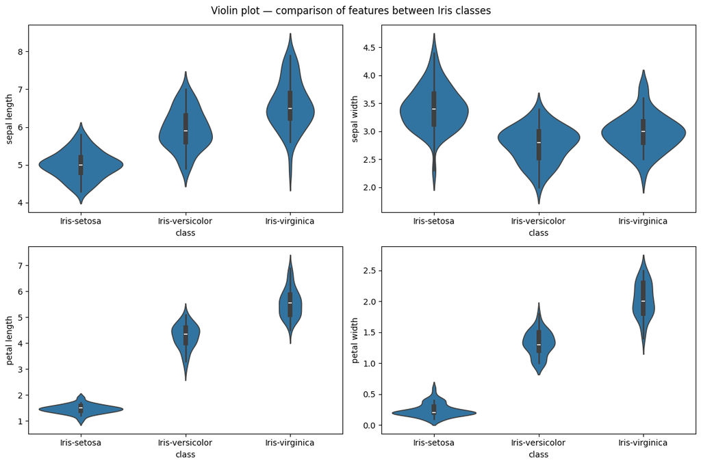

```python
fig, axes = plt.subplots(2, 2, figsize=(12, 8))

sns.violinplot(x="class", y="sepal length", data=df, ax=axes[0, 0])
sns.violinplot(x="class", y="sepal width", data=df, ax=axes[0, 1])
sns.violinplot(x="class", y="petal length", data=df, ax=axes[1, 0])
sns.violinplot(x="class", y="petal width", data=df, ax=axes[1, 1])

plt.suptitle("Violin plot — comparison of features between Iris classes")
plt.tight_layout()
plt.show()
```

##### The violin plot confirms the conclusions drawn from the boxplots.

##### 1. Sepal length

- The three species have values that partially overlap.
- The ranges intersect, so this feature does not distinguish the species very well.

##### 2. Sepal width

- Setosa has slightly wider sepals, but the data is highly varied.
- Versicolor and Virginica have almost identical distributions.
- This feature does not allow for clear species separation.

##### 4. Petal width

- Setosa has the narrowest petals,
- Versicolor and Virginica – increasingly wider.
- The distributions are clearly separated.
- This is also a very good feature for distinguishing between classes.

##### 5. Final conclusions

- Petal features (petal length, petal width) best separate the three iris species.
- Sepal features (sepal length, sepal width) show significant overlap in values, making them less useful for classification.

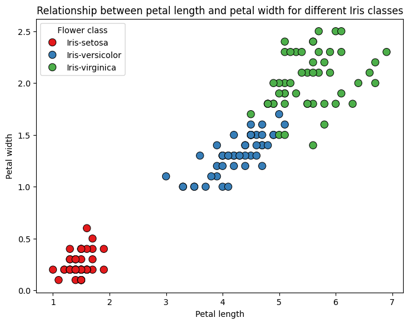

```python
# Now I will examine the relationship between petal length and petal width for different Iris classes
# Scatter plot
plt.figure(figsize=(8,6))
sns.scatterplot(
    data=df,
    x='petal length',
    y='petal width',
    hue='class',          # color based on species
    palette='Set1',       # nice color palette
    s=80,                 # point size
    edgecolor='black'     # point border
)

plt.title("Relationship between petal length and petal width for different Iris classes", fontsize=12)
plt.xlabel("Petal length")
plt.ylabel("Petal width")
plt.legend(title="Flower class")
plt.show()
```

##### The species are well separated — this means that these two features (petal length and petal width) allow very effective class differentiation:

- Iris-setosa (red) has the smallest petals — short and narrow.
- Iris-versicolor (blue) has medium-sized petals.
- Iris-virginica (green) has the largest petals — both longer and wider.

##### The setosa class is completely separated from the others — this means that petal length and width uniquely identify it.

##### Between versicolor and virginica, a small transition zone can be seen — some points are close to each other, but the groups are still clearly separated.

##### In each class, a relationship is visible: the longer the petal, the wider it is. This indicates a positive correlation between these two features.

##### The features (petal length and petal width) are discriminative across the entire Iris dataset — they can be used to predict with high accuracy.

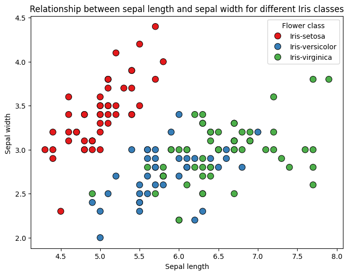

```python
# Checking the relationship between sepal length and sepal width for different Iri
plt.figure(figsize=(8,6))
sns.scatterplot(
    data=df,
    x='sepal length',
    y='sepal width',
    hue='class',          # color based on species
    palette='Set1',       # nice color palette
    s=80,                 # point size
    edgecolor='black'     # point border
)

plt.title("Relationship between sepal length and sepal width for different Iris classes", fontsize=12)
plt.xlabel("Sepal length")
plt.ylabel("Sepal width ")
plt.legend(title="Flower class")
plt.show()
```

##### 1. Iris-setosa (red)

- Forms a clearly distinct cluster – no other species appear in this region.
- Setosa is characterized by wider but shorter sepals.

##### 2. Iris-versicolor (blue)

- Has sepals of medium length and width.
- Partially overlaps with the Iris-virginica region, but not with setosa.
- Versicolor sepals are longer and narrower than those of setosa, but shorter than those of virginica.

##### 3. Iris-virginica (green)

- Has the longest sepals.
- Narrower than those of setosa, often similar in width to versicolor.
- Virginica stands out by its large sepal length, but not necessarily by its width.

##### The Iris-setosa species can be easily distinguished by sepal dimensions alone.

##### The Iris-versicolor and Iris-virginica species partially overlap, which means that sepal dimensions alone are not sufficient for clear differentiation.

```python
# 4. Final conclusions from the data analysis
```

- The conducted analysis showed that sepal features (sepal length and sepal width) do not allow for a clear distinction between the Iris-versicolor and Iris-virginica species.
- The data points corresponding to these species overlap, making it impossible to classify them accurately based solely on sepal dimensions.
- In contrast, the analysis of petal dimensions (petal length and petal width) revealed clear differences among all three species.
- The Iris-setosa species forms a distinct cluster characterized by very small petals.
- Iris-versicolor and Iris-virginica occupy separate regions in the feature space, with increasing values of petal length and width.

##### Based on petal length and width, let’s create a simple function that, given the petal length and width, returns the Iris class:

```python
def classify_iris(petal_length, petal_width):
    if petal_length < 2.5:
        return "Iris-setosa"      # petal lenght < 2.5 cm → setosa
    elif petal_width < 1.8:
        return "Iris-versicolor"   # If not Setosa, then consider the width < 1.8 cm → versicolor
    else:
        return "Iris-virginica"    # Other cases → virginica
```

```python
# Checking accuracy using a loop with our classify_iris function, which iterates over all rows of the DataFrame.
correct = 0
total = len(df)

for i, row in df.iterrows():
    predicted = classify_iris(row['petal length'], row['petal width'])
    if predicted == row['class']:
        correct += 1

accuracy = correct / total * 100
print(f"Classification accuracy: {accuracy:.2f}%")
```

```
Classification accuracy: 96.00%
```

##### Considering the Iris petal dimensions (length and width) allows achieving about 96% accuracy in species identification, confirming that these are key features for effective Iris classification.